# Assignment 3.1 - Plots with R Base Packages

Arpan Sapkota

2023-04-20

## 1. Create a barplot of cyl variable of mtcars data with and without using factor argument

```r
# load the mtcars dataset
data(mtcars)
head(mtcars)
```

```
##                    mpg cyl disp  hp drat    wt  qsec vs am gear carb
## Mazda RX4         21.0   6  160 110 3.90 2.620 16.46  0  1    4    4
## Mazda RX4 Wag     21.0   6  160 110 3.90 2.875 17.02  0  1    4    4
## Datsun 710        22.8   4  108  93 3.85 2.320 18.61  1  1    4    1
## Hornet 4 Drive    21.4   6  258 110 3.08 3.215 19.44  1  0    3    1
## Hornet Sportabout 18.7   8  360 175 3.15 3.440 17.02  0  0    3    2
## Valiant           18.1   6  225 105 2.76 3.460 20.22  1  0    3    1
```

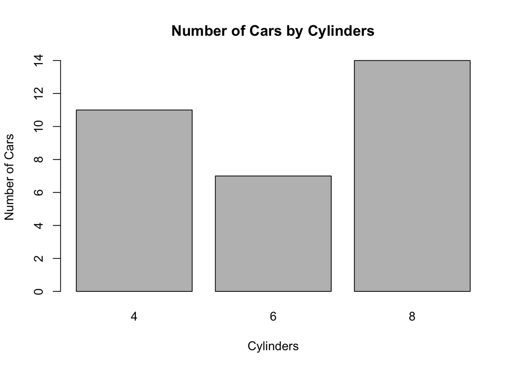

```r
# create a barplot without using factor argument
barplot(table(mtcars$cyl),
        main = "Number of Cars by Cylinders",
        xlab = "Cylinders",
        ylab = "Number of Cars")
```

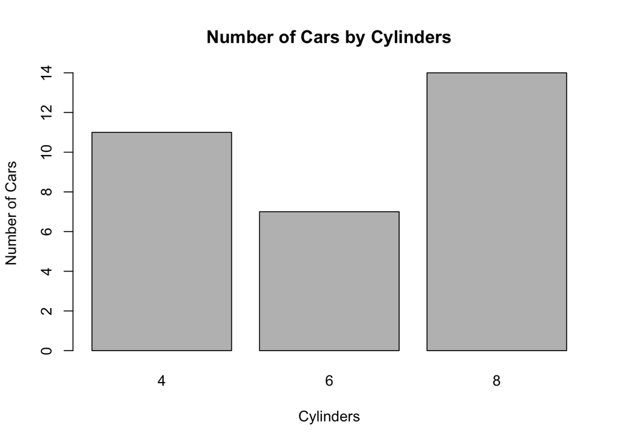

```r
# create a barplot using factor argument
barplot(table(factor(mtcars$cyl, levels = c(4, 6, 8))),
        main = "Number of Cars by Cylinders",
        xlab = "Cylinders",
        ylab = "Number of Cars")
```

## 2. Locate median of mpg variable of mtcars data graphically and compare the median value with in-built function of R

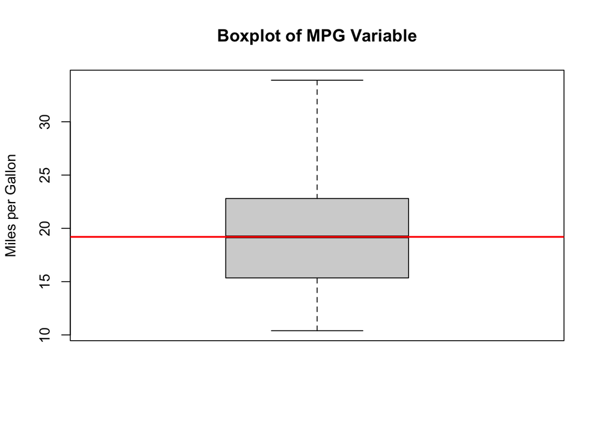

```r
# create a boxplot of mpg variable
boxplot(mtcars$mpg,
        main = "Boxplot of MPG Variable",
        ylab = "Miles per Gallon")
# add a horizontal line at the median value
abline(h = median(mtcars$mpg), col = "red", lwd = 2)
```

```r
# print the median value
cat("Median value of mpg variable (calculated using in-built function):", median(mtcars$mpg))
```

```
## Median value of mpg variable (calculated using in-built function): 19.2
```

As we can see from the output and the plot, the median value of the mpg variable is approximately 19.2. We can confirm this value by using the median function of R, which gives us the same value.

## 3. Locate mode of mpg variable of mtcars data graphically and compare the mode value with the in-built/custom function of R

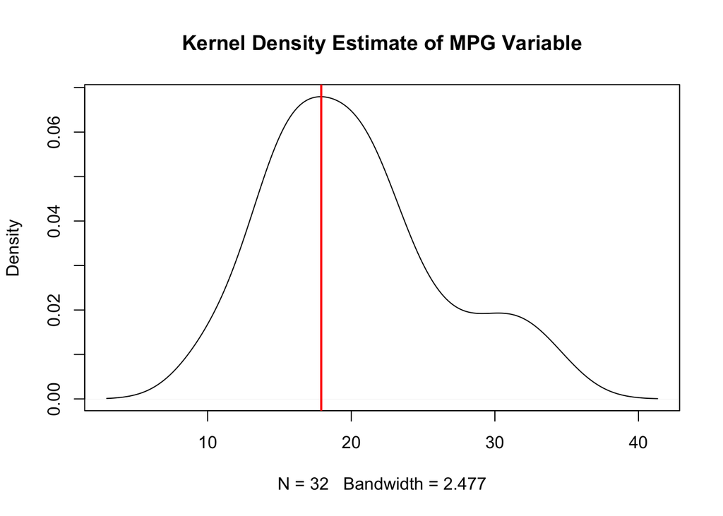

```r
# create a kernel density estimate of the mpg variable
density_mpg <- density(mtcars$mpg)

# plot the kernel density estimate
plot(density_mpg, main = "Kernel Density Estimate of MPG Variable")

# find the mode by locating the peak of the density estimate
mode_mpg <- density_mpg$x[which.max(density_mpg$y)]
abline(v = mode_mpg, col = "red", lwd = 2)
```

```r
# print the mode value
cat("Mode value of mpg variable:", mode_mpg)
```

```
## Mode value of mpg variable: 17.90862
```

As we can see from the output and the plot, the estimated mode value of the mpg variable is approximately 17.90. However, this is just an estimate based on the kernel density estimate, and may not be exactly accurate.

```r
# custom function to calculate the mode of a vector
calculate_mode <- function(x) {
  freq_table <- table(x)

    mode <- names(freq_table)[which.max(freq_table)]

  return(mode)
}

# calculate the mode of the mpg variable using the custom function
mode_mpg <- calculate_mode(mtcars$mpg)
cat("Mode value of mpg variable (calculated using custom function):", mode_mpg)
```

```
## Mode value of mpg variable (calculated using custom function): 10.4
```

## 4. Create a scatterplot of mgp (dependent) and wt (independent) variable of mtcars data, add ablines at mean plus-minus 2 standard deviation and show the name of the cars with mpg > 2 standard deviation from mean inside the scatterplot obtained above

```r
# create a scatterplot of mpg (dependent) and wt (independent) variables
plot(mtcars$wt, mtcars$mpg, main = "Scatterplot of mpg vs. wt", xlab = "Weight (in 1000 lbs)", ylab = "Miles per gallon")

# add ablines at mean plus-minus 2 standard deviation
abline(v = mean(mtcars$wt) - 2*sd(mtcars$wt), lty = 2, col = "red")
abline(v = mean(mtcars$wt) + 2*sd(mtcars$wt), lty = 2, col = "red")
abline(h = mean(mtcars$mpg) - 2*sd(mtcars$mpg), lty = 2, col = "blue")
abline(h = mean(mtcars$mpg) + 2*sd(mtcars$mpg), lty = 2, col = "blue")

# identify cars with mpg > 2 standard deviation from mean
high_mpg_cars <- mtcars[mtcars$mpg > mean(mtcars$mpg) + 2*sd(mtcars$mpg),]
high_mpg_cars
```

```
##                 mpg cyl disp hp drat    wt  qsec vs am gear carb
## Fiat 128       32.4   4 78.7 66 4.08 2.200 19.47  1  1    4    1
## Toyota Corolla 33.9   4 71.1 65 4.22 1.835 19.90  1  1    4    1
```

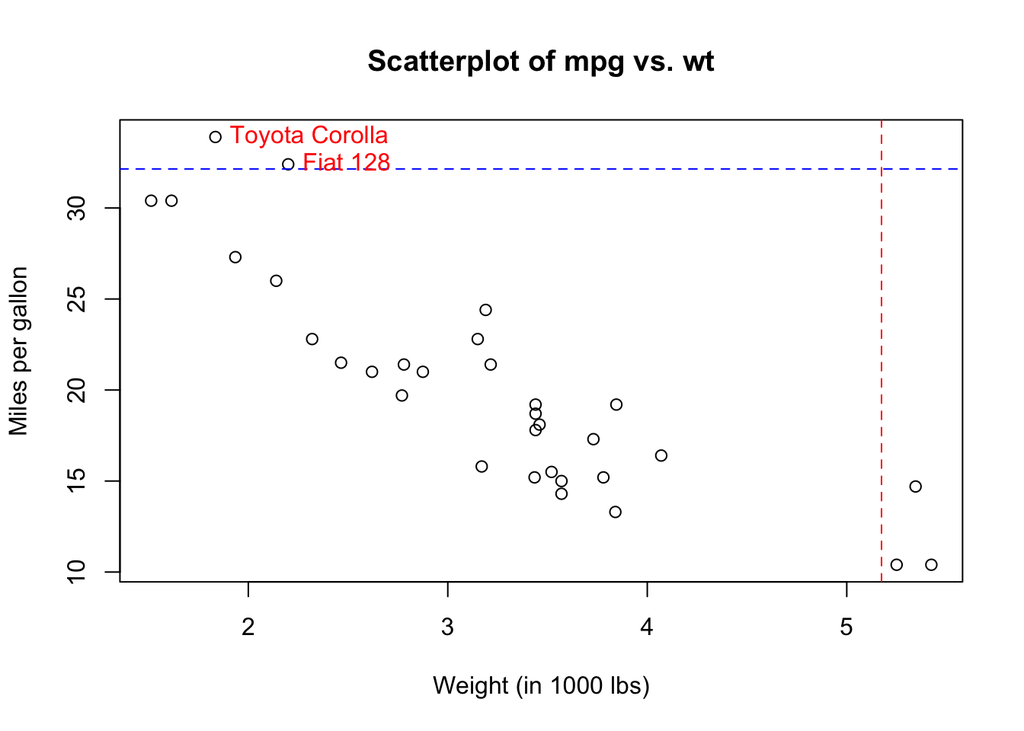

```r
text(high_mpg_cars$wt, high_mpg_cars$mpg, rownames(high_mpg_cars), pos = 4, col = "red")
```

## 5. Create a x variable with 100 random numbers and y variable with x + 100 random numbers; create a factor variable with 100 monthly random observations, create a time series data with 100 random values starting from January 1970; create a date variable with 100 random values starting from 1970/01/01 increasing each day; create a new variable z with square of x variable

```r
# create x and y variables
set.seed(07)
x <- rnorm(100)
y <- x + rnorm(100, mean = 100)

# create factor variable with 100 monthly random observations
set.seed(07)
months <- month.name[1:12]
month_factor <- factor(sample(months, 100, replace = TRUE))

# create time series data with 100 random values starting from January 1970
set.seed(07)
ts_data <- ts(rnorm(100), start = c(1970, 1), frequency = 12)
ts_data
```

```
##               Jan          Feb          Mar          Apr          May
## 1970  2.287247161 -1.196771682 -0.694292510 -0.412292951 -0.970673341
## 1971  2.281451926  0.324020540  1.896067067  0.467680511 -0.893800723
## 1972  1.272916864  0.184192771  0.752279896  0.591745052 -0.983052596
## 1973  0.997513445 -1.105130059 -0.142287831  0.314994905  1.218550535
## 1974  0.100525456  0.931071996 -0.262742349 -0.007668105  0.367153007
## 1975  0.076371474  0.159155278  0.543674185  0.704807353  0.318969143
## 1976 -0.615584207 -0.866659688 -1.639517087 -1.325839244 -0.889036728
## 1977 -0.792704563 -0.311701865 -0.346068592 -0.304607588 -1.785893487
## 1978  1.117993204 -1.540001132 -0.438123899 -0.150672971
##               Jun          Jul          Aug          Sep          Oct
## 1970 -0.947279945  0.748139340 -0.116955226  0.152657626  2.189978107
## 1971 -0.307328300 -0.004822422  0.988164149  0.839750360  0.705341831
## 1972 -0.276063955 -0.870851023  0.718710553  0.110652878 -0.078466768
## 1973 -0.699317079 -0.285432752 -1.311552673 -0.391012431 -0.401526613
## 1974  1.707162545  0.723740263  0.481036049 -1.567868244  0.318250283
## 1975  1.109249789  0.769154195  1.153473675  1.260683503  0.700623507
## 1976 -0.557602330 -0.062402309  2.422692977  0.342585350  0.004248236
## 1977  0.587274672  1.635794434 -0.645423474  0.618992169  0.236393598
## 1978
##               Nov          Dec
## 1970  0.356986230  2.716751783
## 1971  1.305964721 -1.387996217
## 1972 -0.420490459 -0.562125876
## 1973  1.350517581  0.591190027
## 1974  0.165991451 -0.899907630
## 1975  0.432627161 -0.922601718
## 1976  0.029219842 -0.393423429
## 1977  0.846500899 -0.573645739
## 1978
```

```r
# create date variable with 100 random values starting from 1970/01/01 increasing each day
date <- as.Date("1970-01-01") + 0:99
date
```

```
##   [1] "1970-01-01" "1970-01-02" "1970-01-03" "1970-01-04" "1970-01-05"
##   [6] "1970-01-06" "1970-01-07" "1970-01-08" "1970-01-09" "1970-01-10"
##  [11] "1970-01-11" "1970-01-12" "1970-01-13" "1970-01-14" "1970-01-15"
##  [16] "1970-01-16" "1970-01-17" "1970-01-18" "1970-01-19" "1970-01-20"
##  [21] "1970-01-21" "1970-01-22" "1970-01-23" "1970-01-24" "1970-01-25"
##  [26] "1970-01-26" "1970-01-27" "1970-01-28" "1970-01-29" "1970-01-30"
##  [31] "1970-01-31" "1970-02-01" "1970-02-02" "1970-02-03" "1970-02-04"
##  [36] "1970-02-05" "1970-02-06" "1970-02-07" "1970-02-08" "1970-02-09"
##  [41] "1970-02-10" "1970-02-11" "1970-02-12" "1970-02-13" "1970-02-14"
##  [46] "1970-02-15" "1970-02-16" "1970-02-17" "1970-02-18" "1970-02-19"
##  [51] "1970-02-20" "1970-02-21" "1970-02-22" "1970-02-23" "1970-02-24"
##  [56] "1970-02-25" "1970-02-26" "1970-02-27" "1970-02-28" "1970-03-01"
##  [61] "1970-03-02" "1970-03-03" "1970-03-04" "1970-03-05" "1970-03-06"
##  [66] "1970-03-07" "1970-03-08" "1970-03-09" "1970-03-10" "1970-03-11"
##  [71] "1970-03-12" "1970-03-13" "1970-03-14" "1970-03-15" "1970-03-16"
##  [76] "1970-03-17" "1970-03-18" "1970-03-19" "1970-03-20" "1970-03-21"
##  [81] "1970-03-22" "1970-03-23" "1970-03-24" "1970-03-25" "1970-03-26"
##  [86] "1970-03-27" "1970-03-28" "1970-03-29" "1970-03-30" "1970-03-31"
##  [91] "1970-04-01" "1970-04-02" "1970-04-03" "1970-04-04" "1970-04-05"
##  [96] "1970-04-06" "1970-04-07" "1970-04-08" "1970-04-09" "1970-04-10"
```

```r
# create a new variable z with square of x variable
z <- x^2
```

## 6. Create a 2 x 3 plot window with scatterplot, barplot, boxplot, time series plot, date plot and square function plot

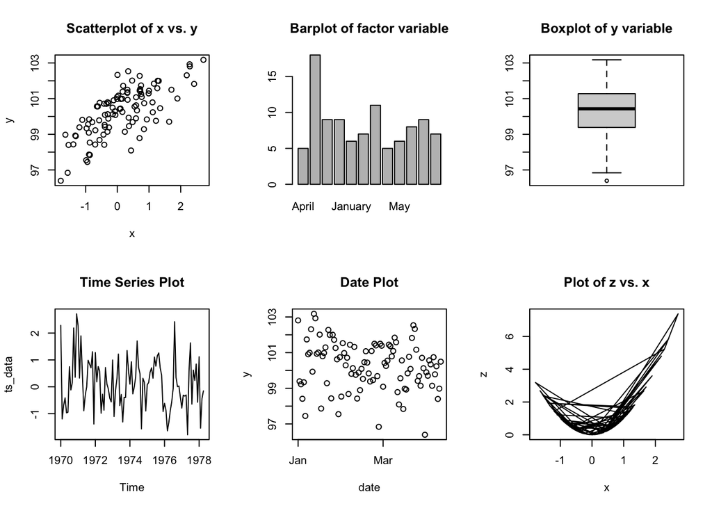

```r
# create a 2 x 3 plot window
par(mfrow = c(2, 3))

# scatterplot of x vs. y
plot(x, y, main = "Scatterplot of x vs. y")

# barplot of factor variable
barplot(table(month_factor), main = "Barplot of factor variable")

# boxplot of y variable
boxplot(y, main = "Boxplot of y variable")

# time series plot of ts_data
plot(ts_data, main = "Time Series Plot")

# date plot of date vs. y
plot(date, y, main = "Date Plot")

# plot of z vs. x using the square function
plot(x, z, main = "Plot of z vs. x", type = "l")
```

## 7. Perform log transformation on x and z variables i.e. log of x, log of z and log of x and z in the plot command and interpret the results carefully

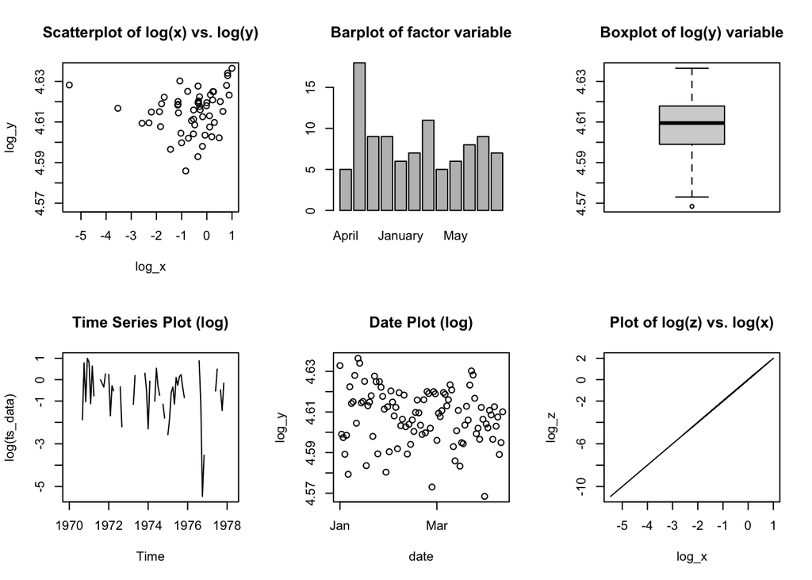

```r
# perform log transformation on x and z variables
log_x <- log(x)
log_y <- log(y)
log_z <- log(z)
log_xz <- log(x*z)

# perform log transformation on x and z variables and create plots
par(mfrow = c(2, 3))

# scatterplot of log(x) vs. log(y)
plot(log_x, log_y, main = "Scatterplot of log(x) vs. log(y)")

# barplot of factor variable
barplot(table(month_factor), main = "Barplot of factor variable")

# boxplot of log(y) variable
boxplot(log_y, main = "Boxplot of log(y) variable")

# time series plot of log(ts_data)
plot(log(ts_data), main = "Time Series Plot (log)")

# date plot of date vs. log(y)
plot(date, log_y, main = "Date Plot (log)")

# plot of log(z) vs. log(x) using the square function
plot(log_x, log_z, main = "Plot of log(z) vs. log(x)", type = "l")
```

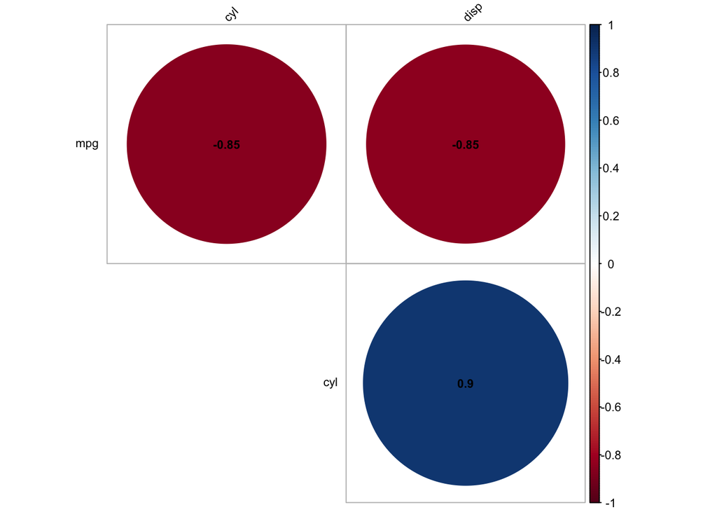

```r
#Resetting the previous windows size
par(mfrow = c(1, 1))

# Select first three numerical variables
mtcars_subset <- mtcars[, c("mpg", "cyl", "disp")]

# Create correlation matrix
cor_matrix <- cor(mtcars_subset)

# Create correlation matrix plot
#install.packages("corrplot")
library(corrplot)
corrplot(cor_matrix, method = "circle", type = "upper", order = "hclust",
         tl.col = "black", tl.srt = 45, addCoef.col = "black",
         number.cex = 0.7, tl.cex = 0.7, cl.cex = 0.7, diag = FALSE)
```

**Advantages of plots created using R base packages:**  
* R base packages provide a wide range of plot types and options for customization.  
* R base plots can be generated quickly and easily, making them a good choice for exploratory data analysis and rapid prototyping.  
* R base plots can be easily embedded in reports and presentations, making them a useful tool for communication.

**Limitations of plots created using R base packages:**  
* R base plots can be limited in terms of aesthetic appeal and customization options compared to more advanced plotting libraries.  
* R base plots may not be well-suited for complex visualizations or large datasets, as they may not be optimized for speed or memory usage.  
* The syntax for generating R base plots are difficult to learn for new users, especially for more complex plots.

R base plots provide a useful starting point for generating simple visualizations quickly and easily, but may not be the best choice for complex or highly customized plots. While they are widely available and can be useful for communication, they may not be optimized for performance and may not offer the same level of customization as more advanced plotting libraries.